# 第8回 クラスタリング：k-meansと階層的クラスタリング

## 前回からの接続

第7回は、ネットショップの訪問から購入を見分け、2つの誤りの重さでしきい値を決めました。第6・7回のデータには、当てたい答えの列（迷惑か、購入か）がありました。

今日のデータには、答えの列がありません。答えの列が無いまま、似た行どうしをまとめて群に分けます。

## 今日の分析目標

答えの列が無い星を、似たものどうしでまとめると、星の種類が分かれるか。何個に、どう分ければよいかに答える。

まず、星の視差から距離と本当の明るさ（絶対等級）を出し、色と並べて図を描きます。次に、k-meansで星を2つに分け、目で見える星の種類と比べます。そして、k-meansの中で何をくり返しているかを読み、なぜその分け方になったかを確かめます。さらに、群の数を替えて、群の数の指針を並べます。最後に、近い星どうしをつないでいく階層的クラスタリングで分け、k-meansと比べます。

もう1つのねらいは、止まる条件を書いて、`while`で「動かなくなるまで」くり返す手順を読めるようになることです。k-meansの中身を`while`で書いたものを、1行ずつ読みます。お手本ごとに、コードを1行ずつ読み（「1行ずつ読む」）、変数の中身を見ます（「中身を見る」）。

### 公開データの世界

ヨーロッパ宇宙機関（ESA）の衛星Gaiaは、空の星の位置・明るさ・色を測り続けています。測った値は、誰でも使える公開データとして配られています。今日は、太陽のまわりの星を、そこから取ってきました。

### 場面

夜空の星は、どれも同じに見えます。でも、色と本当の明るさを並べると、星の種類が分かれて見えます。天文学者は、その図を見て、星の種類を見分けてきました。

答えの列（この星は何の種類か）が無いまま、星を似たものどうしでまとめたい。まとめた群が、天文学者の見分ける種類と合うかを確かめます。

似た行どうしをまとめて、いくつかの群に分けることを、クラスタリング（clustering）といいます。群のことをクラスターともいいます。答えの列は使わず、データの値の近さだけで分けます。今日は、いちばん基本の方法、k-meansと、階層的クラスタリングを使います。

### 手元のデータ

Gaia第3版（DR3）から、太陽の近くの星を、測りの質の条件で絞って取りました。1行が星1つで、27,860個あります。列は、視差（`parallax`）・見かけの等級（`phot_g_mean_mag`）・色（`bp_rp`）の3本と、星の番号（`source_id`）です。答えの列はありません。

データはESAのGaiaアーカイブで公開されていて（CC BY-SA 3.0 IGO）、出典（Gaia Collaboration, Vallenari et al., 2023）とESAへのクレジットを書けば使えます。

### 最後に出す答え

星を似たものどうしでまとめると、星の種類が分かれるか。分かれないなら、なぜか。何個に、どう分ければよいかです。

### 今日の一周（結果だけ先に）

コードの説明はあとにして、今日の解析を、結果だけで一度通して見ておきます。

1. 知って分ける：色と本当の明るさを並べると（HR図）、長い帯の主系列と、左下の小さな帯の白色矮星が見えます。えっ、k-meansで2つに分けると、白色矮星が真っ二つになります。主系列も、途中で輪切りになります。
2. くり返しを読む：k-meansは、近い中心の群に入れ、中心を群の平均へ動かすことを、動かなくなるまでくり返します。中心までの距離の二乗和を小さくするので、見た目どおりの分け方より、輪切りのほうを選びます。止まる所は、出発点しだいで変わります。
3. 群の数を決める：エルボー法（elbow method）なら2つ、シルエット（silhouette）という指針では3つがいちばん良くなります。別の指針Gapは、8まで伸び続け、どの数も選びません。
4. つなぎ方を替える：近い星どうしを鎖のようにつなぐ階層的クラスタリングなら、2つの帯がそのまま分かれます。

このあと、この4つの段の中身を、1つずつ開けていきます。

### 今日の問いとやること

| 段 | 問い | やること |
| --- | --- | --- |
| 知って分ける（1・2節） | 2つの帯に分かれる？ | 視差から本当の明るさを出してHR図を描き、標準化してk-meansで2つに分ける |
| くり返しを読む（3節） | 何をくり返している？ | `while`で書いたk-meansを1行ずつ読み、二乗和と、止まる所を比べる |
| 群の数を決める（4節） | 何個に分ければよい？ | 群の数を替えて、二乗和・Gap・シルエットを並べる |
| つなぎ方を替える（5節） | 帯のまま分けられる？ | 近い星からつないでいく階層的クラスタリングで分け、樹形図を読む |

### 今日の進め方

段ごとに、まずスライドで、その段の結論までを通して聞きます。段の終わりにノートへ移り、その段の節のセルを上から実行して、スライドと同じ数が出るかを確かめます。そして、段ごとに1つあるTODOに答えます。

TODOは、実行の前に結果を予想して書き、1か所を替えて実行し、予想と比べる形です。予想が外れても、かまいません。

## 学習ゴール

この回を終えると、次のことができるようになります。

- 視差から距離と絶対等級を出し、HR図を描いて、星の種類を読める
- 列を標準化（standardization）してから、k-meansで行を群に分け、群を図に塗って読める
- k-meansの割り当てと更新を、`while`で「動かなくなるまで」くり返すコードとして読める
- k-meansが距離の二乗和を小さくするので、丸い群を探し、細長い群は輪切りにすることを説明できる
- 群の数を替えて、二乗和・Gap・シルエットを並べ、指針の限界を踏まえて群の数を決められる
- k-meansが出発点しだいで違う所に止まること（局所解）と、`n_init`で何通りも試す理由を説明できる
- 階層的クラスタリングで分け、つなぎ方（単連結・ウォード法）によって群が変わることを、樹形図とともに説明できる

## 0. 準備

### 最初に実行する：道具を呼び出す

- 役割：このノートで使う道具（ライブラリ）を呼び出す
- 入力：なし
- 出力：なし（終わるとセルの左に ✓ が付く）

```python
import numpy as np
import pandas as pd
import matplotlib.pyplot as plt
```

### 図の日本語を表示できるようにする

- 役割：図の中の日本語が □ にならないようにし、図の大きさと字の大きさをそろえる
- 入力：なし
- 出力：「セットアップ完了」の表示

`try:`から先は、日本語表示の道具が動かなくなったときの保険で、中身は読まなくてかまいません。

```python
# 日本語が図の中で □ になるのを防ぐ
!pip install -q japanize-matplotlib
try:
    import japanize_matplotlib
# japanize が動かなくなったときの保険：同梱フォントを直接登録する
except Exception:
    from importlib.util import find_spec
    from matplotlib import font_manager as fm
    from pathlib import Path
    spec = find_spec('japanize_matplotlib')
    ttf = None
    if spec:
        ttf = next(Path(spec.origin).parent.rglob('*.ttf'), None)
    if ttf:
        fm.fontManager.addfont(str(ttf))
        name = fm.FontProperties(fname=str(ttf)).get_name()
        plt.rcParams['font.family'] = name

plt.rcParams['figure.figsize'] = (9, 5)
plt.rcParams['font.size'] = 13
plt.rcParams['axes.unicode_minus'] = False  # マイナス記号の化けを防ぐ
print('セットアップ完了')
```

```
セットアップ完了
```

## 1. 星の何を比べる？

ここから、段1「知って分ける」（1・2節）です。問いは、星を2つに分けると、主系列と白色矮星に分かれるか、です。

まず、表を読み込み、3本の列の意味を読みます（1節）。そのあと、k-meansで分けます（2節）。

### お手本：表を読み込む

- 役割：星の表を読み込み、星の数を数えて、先頭3行を見る
- 入力：データの置き場所`DATA_DIR`と、ファイル名`gaia_nearby.csv`
- 出力：表`raw`（27,860個）

```python
# データはこのリポジトリから読み込む
DATA_DIR = ('https://raw.githubusercontent.com/k0heiun0/'
            'applied_exercise_preview/main/shared/data')
raw = pd.read_csv(f'{DATA_DIR}/gaia_nearby.csv')
print(len(raw), '個')
raw.head(3)
```

```
27860 個
```

|  | source_id | parallax | phot_g_mean_mag | bp_rp |
| --- | --- | --- | --- | --- |
| 0 | 123424475948672 | 22.499347 | 14.900652 | 3.198625 |
| 1 | 452212812313984 | 24.114540 | 13.457018 | 2.572324 |
| 2 | 630505494719360 | 67.933502 | 8.457596 | 1.727691 |

#### 1行ずつ読む

- `DATA_DIR`の行：データの置き場所を`DATA_DIR`にしまう（Colabでは、置き場所のURLが2行に分かれて入っている）
- `pd.read_csv`の行：置き場所の`gaia_nearby.csv`を読み、表`raw`にしまう
- `print`の行と最後の行：星の数を表示し、先頭3行を見る

### 3本の列

| 列 | 意味 |
| --- | --- |
| `parallax` | 視差（ミリ秒角）。大きいほど近い |
| `phot_g_mean_mag` | 見かけの等級。地球から見た明るさ。小さいほど明るい |
| `bp_rp` | 色。青で測った等級と赤で測った等級の差。小さいほど青く、熱い |

地球は1年かけて太陽のまわりを回ります。半年たつと、地球の位置が変わるので、近い星ほど、遠くの星に対して大きくずれて見えます。このずれの角度が視差です。視差から、星までの距離が分かります。

### お手本：列の名前を日本語に

- 役割：英語の列の名前を、日本語の名前に替える
- 入力：表`raw`と、名前の組の辞書`names`
- 出力：表`df`

```python
names = {'parallax': '視差', 'phot_g_mean_mag': '見かけの等級',
         'bp_rp': '色'}
df = raw.rename(columns=names)
df.head(3)
```

|  | source_id | 視差 | 見かけの等級 | 色 |
| --- | --- | --- | --- | --- |
| 0 | 123424475948672 | 22.499347 | 14.900652 | 3.198625 |
| 1 | 452212812313984 | 24.114540 | 13.457018 | 2.572324 |
| 2 | 630505494719360 | 67.933502 | 8.457596 | 1.727691 |

#### 1行ずつ読む

- 1・2行目：元の名前を鍵に、日本語の名前を値にした辞書を作る（第5回）
- 3行目：辞書のとおりに列の名前を替え、表`df`にしまう
- 4行目：先頭3行を見る

### 見かけの明るさと、本当の明るさ

同じ明るさの星でも、遠くにあれば暗く見えます。星そのものの明るさを比べるには、距離をそろえる必要があります。星を10パーセクの距離に並べたときの等級を、絶対等級といいます。

視差$\varpi$（ミリ秒角）から、距離$d$（パーセク）を出します。

$$d = \frac{1000}{\varpi}$$

見かけの等級$m$と距離$d$から、絶対等級$M$を出します。

$$M = m - 5 \log_{10} \frac{d}{10}$$

### お手本：距離と絶対等級

- 役割：式のとおりに、距離と絶対等級の列を作る
- 入力：表`df`の視差と見かけの等級
- 出力：表`df`に足した列「距離」「絶対等級」

```python
df['距離'] = 1000 / df['視差']
df['絶対等級'] = df['見かけの等級'] - 5 * np.log10(df['距離'] / 10)
print(df['距離'].round(1).max())
df[['視差', '距離', '見かけの等級', '絶対等級']].head(3).round(2)
```

```
50.0
```

|  | 視差 | 距離 | 見かけの等級 | 絶対等級 |
| --- | --- | --- | --- | --- |
| 0 | 22.50 | 44.45 | 14.90 | 11.66 |
| 1 | 24.11 | 41.47 | 13.46 | 10.37 |
| 2 | 67.93 | 14.72 | 8.46 | 7.62 |

#### 1行ずつ読む

- 1行目：1000を視差で割って、距離の列を作る
- 2行目：式のとおりに、絶対等級の列を作る（`np.log10`は常用対数）
- 3・4行目：いちばん遠い星の距離と、先頭3行を見る

いちばん遠い星でも、50パーセクです。太陽のまわりの、ごく近い星だけを取りました。

### お手本：HR図を描く

- 役割：横に色、縦に絶対等級をとって、星を点で打つ
- 入力：表`df`の色と絶対等級
- 出力：図（HR図）

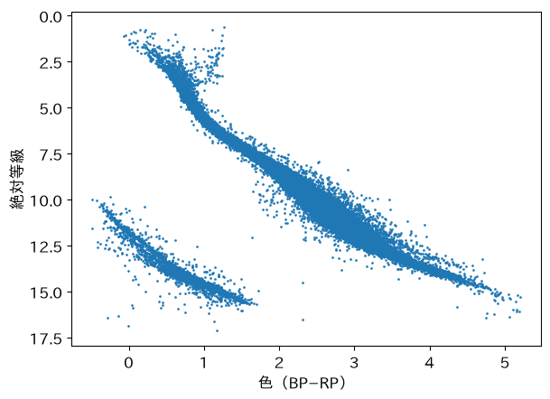

```python
plt.figure(figsize=(7, 5))
plt.scatter(df['色'], df['絶対等級'], s=1)
plt.gca().invert_yaxis()
plt.xlabel('色（BP−RP）')
plt.ylabel('絶対等級')
plt.show()
```

#### 1行ずつ読む

- 1行目：図の大きさを決める
- 2行目：横に色、縦に絶対等級をとり、星を1つずつ点で打つ（`s=1`は小さな点）
- 3行目：縦軸を上下逆にする。等級は小さいほど明るいので、明るい星を上にする
- 4〜6行目：軸の名前を付けて、図を表示する

### HR図を読む

この図を、ヘルツシュプルング・ラッセル図（HR図）といいます。

- 主系列：右下から左上へのびる長い帯。太陽の仲間で、中心で水素を燃やして光る。青く熱い星ほど明るい
- 白色矮星：左下の小さな帯。燃え尽きた星の芯。小さいので、熱く青くても暗い
- 巨星：右上の小さな塊。年老いてふくらんだ星。赤いのに明るい。この近さには少ない

### お手本：白色矮星を数える

- 役割：図を見て、2つの帯のあいだに直線を引き、線より下（暗い側）を白色矮星とする
- 入力：表`df`の色と絶対等級
- 出力：列「白色矮星」（白色矮星なら1）と、その数

```python
df['白色矮星'] = (df['絶対等級'] > 4 * df['色'] + 8.5).astype(int)
print(df['白色矮星'].sum(), '個')
```

```
2027 個
```

#### 1行ずつ読む

- 1行目：絶対等級が「4×色＋8.5」より大きい（暗い）星を1、それ以外を0にした列を作る
- 2行目：1の数、つまり白色矮星の数を表示する

この列は、図を見て決めた答えのようなものです。k-meansには渡しません。分けたあとの答え合わせだけに使います。k-meansが使うのは、色と絶対等級の2本だけです。

### 結果を見る前に、予想を書く

星を2つに分けたら、主系列と白色矮星に分かれるでしょうか。目で見ると、2つの帯ははっきり離れています。予想と、その理由を1行で書いてください。

（ここに予想を書く）

## 2. 2つに分けると？

視差から距離と絶対等級を出し、色と並べてHR図を描きました。目で見ると、長い帯の主系列と、左下の白色矮星（2,027個）の2種類です。ここから、値の近さだけで、星を2つに分けます。

### 近さは、距離で測る

2つの星の近さを、図の上の距離で測ります。色と絶対等級の差を、それぞれ2乗して足したもの（距離の2乗）です。単位がばらばらだと、幅の大きい列の差ばかりが効いてしまいます。絶対等級のほうが、色よりずっと広く散らばるので、このままだと明るさの差ばかりで分けてしまいます。

### お手本：標準化する

- 役割：2本の列を、平均0・標準偏差（standard deviation）1にそろえる（第7回のおさらい）
- 入力：表`df`の色と絶対等級
- 出力：配列`X`（星の数×2）

```python
from sklearn.preprocessing import StandardScaler
X = StandardScaler().fit_transform(df[['色', '絶対等級']])
print(X[:3].round(2))
```

```
[[ 0.89  0.54]
 [ 0.25  0.08]
 [-0.6  -0.88]]
```

#### 1行ずつ読む

- 1行目：標準化の道具を呼び出す
- 2行目：2本の列を、平均0・標準偏差1にそろえ、配列`X`にしまう
- 3行目：先頭3つの星の、標準化した値を見る。1列目が色、2列目が絶対等級

### k-means

群の数$k$を先に決めます。今日は、まず$k=2$です。中心を$k$個置き、星をいちばん近い中心の群に入れます。中心の置き方は、道具`KMeans`が決めます。中身は3節で読みます。

### お手本：2つに分ける

- 役割：標準化した2本の列で、星を2つの群に分ける
- 入力：配列`X`と、群の数2
- 出力：列「群」（0か1）と、群ごとの星の数

```python
from sklearn.cluster import KMeans
km = KMeans(2, n_init=10, random_state=0)
km.fit(X)
df['群'] = km.labels_
print(df['群'].value_counts())
```

```
群
0    19806
1     8054
Name: count, dtype: int64
```

#### 1行ずつ読む

- 1行目：k-meansの道具`KMeans`を呼び出す
- 2行目：群の数2で準備する。`n_init=10`は出発点を10通り試す設定、`random_state`は乱数（random number）のシード
- 3行目：`X`に当てはめて、2つに分ける
- 4行目：星ごとの群の番号（0か1）を`km.labels_`から取り、列「群」にする
- 5行目：群ごとの星の数を数える

#### 中身を見る：群の番号

```python
df[['色', '絶対等級', '群']].head(3).round(2)
```

|  | 色 | 絶対等級 | 群 |
| --- | --- | --- | --- |
| 0 | 3.20 | 11.66 | 0 |
| 1 | 2.57 | 10.37 | 0 |
| 2 | 1.73 | 7.62 | 1 |

星1つに、群の番号が1つ付きました。番号の0と1は、名前にすぎません。

### お手本：群で塗る

- 役割：HR図の点を、群の番号ごとに色を変えて打つ
- 入力：表`df`の色・絶対等級・群
- 出力：図

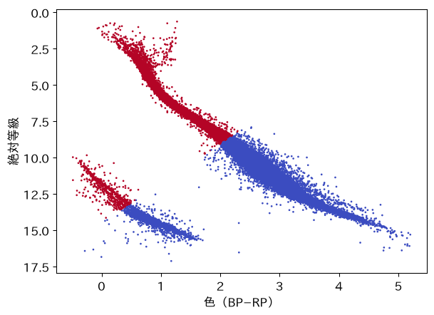

```python
plt.figure(figsize=(7, 5))
plt.scatter(df['色'], df['絶対等級'], s=1, c=df['群'],
            cmap='coolwarm')
plt.gca().invert_yaxis()
plt.xlabel('色（BP−RP）')
plt.ylabel('絶対等級')
plt.show()
```

#### 1行ずつ読む

- 2・3行目：1節のHR図と同じ点を打ち、`c=df['群']`で、群の番号ごとに色を変える（`cmap`は色の組）
- ほかの行は、1節のHR図と同じ

えっ、白色矮星の帯が、途中で切られました。主系列も、真ん中で切られています。

### お手本：目安の線と比べる

- 役割：目安の線（白色矮星か）と、k-meansの群を、組ごとに数える
- 入力：列「白色矮星」と列「群」
- 出力：2×2の表

```python
pd.crosstab(df['白色矮星'], df['群'])
```

| 群 白色矮星 | 0 | 1 |
| --- | --- | --- |
| 0 | 18384 | 7449 |
| 1 | 1422 | 605 |

#### 1行ずつ読む

- 1行目：目安の線の0・1と、群の0・1の組み合わせごとに、星の数を数える（`pd.crosstab`、第7回）

白色矮星2,027個のうち、1,422個が群0、605個が群1に入りました。白色矮星は2つの群に割れ、どちらの群にも、主系列と白色矮星がまざっています。目で見てはっきり離れた2つの帯を、k-meansは2つに分けませんでした。

> 重要：k-meansの群の番号は、名前にすぎない。番号が何の群かは、分けたあとに中身を見て読む。

### TODO①：群の数を替える（予想 → 実行 → 比べる）

下のセルは、k-meansで星を分け、目安の線と組ごとに数えます。

まず、予想を書いてください。3つに分けると、白色矮星は1つの群にまとまるでしょうか。

（ここに予想を書く）

予想を書いたら、セルの`2`を`3`に替えて実行してください。

```python
# TODO: 2 を 3 に替えて実行する
km_x = KMeans(2, n_init=10, random_state=0)
km_x.fit(X)
pd.crosstab(df['白色矮星'], km_x.labels_)
```

| col_0 白色矮星 | 0 | 1 |
| --- | --- | --- |
| 0 | 18384 | 7449 |
| 1 | 1422 | 605 |

### やってみよう：予想と比べる

実行した結果を、予想と比べてください。白色矮星は、1つの群にまとまりましたか。主系列はどうなりましたか。

（ここに答えを書く）

3つにすると、白色矮星2,027個は1つの群にまとまります。かわりに、主系列が2つの群に切られます。目で見える2種類に、群の数をいくつ足しても、主系列は切られ続けます。

### ここまでで分かったこと

| 段 | 分かったこと |
| --- | --- |
| 知って分ける（1・2節） | HR図に主系列と白色矮星。k-meansで2つに分けると、白色矮星が1,422個と605個に割れる |
| くり返しを読む（3節） | ？（このあとの段で） |
| 群の数を決める（4節） | ？（このあとの段で） |
| つなぎ方を替える（5節） | ？（このあとの段で） |

まだ分からないのは、k-meansが中で何をしていて、なぜ輪切りにしたか、です。

## 3. 何をくり返している？

ここから、段2「くり返しを読む」（3節）です。問いは、k-meansは何をくり返していて、なぜ輪切りにしたのか、です。

k-meansで2つに分けると、白色矮星が2つの群に割れました。3つに分けると白色矮星はまとまりますが、主系列が切られます。ここから、`KMeans`の中で何をしているかを読みます。

### k-meansの手順

1. 中心を2つ置く（出発点）
2. 星を、いちばん近い中心の群に入れる（割り当て）
3. 中心を、群の星の平均へ動かす（更新）

2と3を、中心が動かなくなるまでくり返します。

星$i$の値を$x_i$、群$j$の中心を$\mu_j$とします。

- 割り当て：$c_i = \arg\min_j \|x_i - \mu_j\|^2$（いちばん近い中心の番号）
- 更新：$\mu_j = \dfrac{1}{n_j} \sum_{c_i = j} x_i$（群$j$の$n_j$個の星の平均）

### 何回くり返せばよい？

中心が動かなくなるまでです。それが何回目かは、やってみるまで分かりません。`for`は、回数を先に決めてくり返します（`range(3)`なら3回）。回数が先に決まらないくり返しには、`while`を使います。

### while：最小の例

- 役割：`x`を2倍し続け、100以上になったら止める
- 入力：なし
- 出力：止まったときの`x`

```python
x = 1
while x < 100:
    x = x * 2
print(x)
```

```
128
```

#### 1行ずつ読む

- 1行目：`x`を1にする
- 2行目：「`x`が100より小さいあいだ」、字下げした行をくり返す
- 3行目：`x`を2倍にする
- 4行目：くり返しが終わったら、`x`を表示する

#### 中身を見る：xの動き

```python
x = 1
while x < 100:
    x = x * 2
    print(x)
```

```
2
4
8
16
32
64
128
```

128になったところで、条件「100より小さい」を満たさなくなり、止まります。

### お手本：近い中心の群に入れる

- 役割：割り当て（手順2）を、関数`assign`にする
- 入力：星`X`と、2つの中心`C`
- 出力：星ごとの群の番号（0か1）

```python
def assign(X, C):
    d0 = ((X - C[0]) ** 2).sum(axis=1)
    d1 = ((X - C[1]) ** 2).sum(axis=1)
    return (d1 < d0).astype(int)
```

#### 1行ずつ読む

- 1行目：関数`assign`を作る。入力は星`X`と中心`C`
- 2行目：星ごとに、中心0までの距離の2乗を出す（色と絶対等級の差を2乗して、横に足す）
- 3行目：同じく、中心1までの距離の2乗を出す
- 4行目：中心1のほうが近ければ1、そうでなければ0を返す

### お手本：中心を平均へ動かす

- 役割：更新（手順3）を、関数`update`にする
- 入力：星`X`と、群の番号`lab`
- 出力：新しい2つの中心

```python
def update(X, lab):
    c0 = X[lab == 0].mean(axis=0)
    c1 = X[lab == 1].mean(axis=0)
    return np.array([c0, c1])
```

#### 1行ずつ読む

- 1行目：関数`update`を作る。入力は星`X`と群の番号`lab`
- 2行目：群0の星だけを取り出し、列ごとの平均（色の平均、絶対等級の平均）を出す
- 3行目：群1も同じ
- 4行目：2つの中心を、1つの配列にまとめて返す

### お手本：動かなくなるまでくり返す

- 役割：割り当てと更新を、中心が動かなくなるまでくり返す
- 入力：星`X`と、出発点（0番目と1番目の星）
- 出力：止まるまでの回数`n`、群の番号`lab`、中心`C`

```python
C = X[[0, 1]]
n = 0
moved = 1.0
while moved > 0:
    lab = assign(X, C)
    C_new = update(X, lab)
    moved = np.abs(C_new - C).max()
    C = C_new
    n = n + 1
print(n, '回で止まった')
```

```
17 回で止まった
```

#### 1行ずつ読む

- 1行目：出発点。0番目と1番目の星を、2つの中心にする
- 2・3行目：回数`n`を0に、中心の動き`moved`を仮に1にする（最初の1回を必ず回すため）
- 4行目：「中心が少しでも動いたあいだ」、字下げした行をくり返す
- 5・6行目：割り当てて、新しい中心を出す
- 7行目：新しい中心と古い中心の差のうち、いちばん大きいものを`moved`にする
- 8・9行目：中心を入れ替え、回数を1増やす
- 10行目：止まったら、回数を表示する

#### 中身を見る：最初の3回

くり返しを3回だけ回し、中心の動きと、中心までの距離の二乗和を表示します。名前は`C2`のように替え、上の`C`や`lab`を壊さないようにします。

```python
C2 = X[[0, 1]]
for r in range(3):
    lab2 = assign(X, C2)
    C2_new = update(X, lab2)
    moved2 = np.abs(C2_new - C2).max()
    ss2 = ((X - C2_new[lab2]) ** 2).sum()
    print(r + 1, moved2.round(3), ss2.round(1))
    C2 = C2_new
```

```
1 0.76 33009.6
2 0.229 28617.2
3 0.182 26097.0
```

中心の動きは小さくなっていきます。右の数は、中心までの距離の二乗和（群内平方和）です。二乗和は、割り当てでも更新でも増えません。だから、いつかは動かなくなって止まります。

### whileがしていること

毎回、中身の前に条件（`moved > 0`）を確かめます。満たしていれば、中身を1回（割り当て → 平均へ → `moved`を測る）行い、条件に戻ります。満たさなくなったら、くり返しを抜けて、次の行へ進みます。

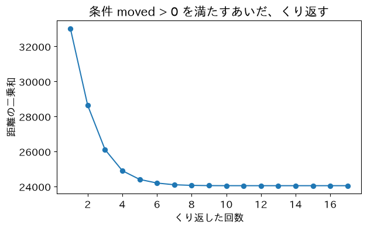

```
     回  中心の動き        二乗和
14  15  0.001  24035.495
15  16  0.000  24035.492
16  17  0.000  24035.492
```

> 今日の重要概念（Python）：while

> whileは、条件を満たすあいだ、くり返す。何回で終わるかが先に決まらないくり返しに使う。

### お手本：KMeansと比べる

- 役割：同じ出発点から`KMeans`を当てはめ、自分でくり返した答えと比べる
- 入力：配列`X`と、出発点
- 出力：くり返した回数と、群の番号がすべて同じか

```python
km_s = KMeans(2, init=X[[0, 1]], n_init=1, tol=0)
km_s.fit(X)
print(km_s.n_iter_, (km_s.labels_ == lab).all())
```

```
17 True
```

#### 1行ずつ読む

- 1行目：出発点を0番目と1番目の星にし（`init`）、出発点は1通りだけ（`n_init=1`）、止まる条件はぴったり動かなくなるまで（`tol=0`）
- 2行目：当てはめる
- 3行目：くり返した回数と、群の番号がすべて同じか（`all`）を表示する

同じ出発点から始めると、`KMeans`も同じ回数で止まり、群の番号もすべて同じです。`KMeans`の中でしていることは、上の`while`と同じです。

### お手本：見た目どおりから始める

では、目安の線の分け方（主系列と白色矮星）から始めたら、k-meansはどう動くでしょうか。

- 役割：目安の線の群で中心を出し、もう一度割り当てる
- 入力：配列`X`と、列「白色矮星」
- 出力：群を移った星の数

```python
eye = df['白色矮星'].values
C_eye = update(X, eye)
lab_eye = assign(X, C_eye)
print((lab_eye != eye).sum(), '個が群を移る')
```

```
3 個が群を移る
```

#### 1行ずつ読む

- 1行目：目安の線の0・1を、群の番号として取り出す
- 2・3行目：その群で中心を出し（更新）、もう一度割り当てる
- 4行目：番号が変わった星の数を表示する

3個だけです。見た目どおりの分け方も、k-meansの手順ではほとんど動かず、そこで止まります。止まる先は、出発点しだいで1つではありません。では、`KMeans`は、なぜ輪切りのほうを選んだのでしょうか。

### お手本：二乗和を比べる

- 役割：分け方ごとに、中心までの距離の二乗和を出して比べる
- 入力：配列`X`と、群の番号
- 出力：見た目どおりの分け方と、k-meansの分け方の二乗和

```python
def ss(X, lab):
    C = update(X, lab)
    return round(((X - C[lab]) ** 2).sum())

print(ss(X, eye), ss(X, lab))
```

```
45877 24035
```

#### 1行ずつ読む

- 1行目：関数`ss`を作る。入力は星`X`と群の番号`lab`
- 2行目：群ごとの中心を出す
- 3行目：`C[lab]`は星ごとの「自分の群の中心」。差を2乗して全部足し、整数に丸めて返す
- 5行目：見た目どおりの分け方と、k-meansの分け方で比べる

見た目どおりの分け方は45,877、k-meansの輪切りは24,035です。輪切りのほうが、二乗和が2倍近く小さいのです。`n_init=10`は、10通りの出発点から始め、二乗和がいちばん小さい答えを選びます。だから、`KMeans`は輪切りを選びました。

主系列は長い帯です。中心を1つにすると、帯の端の星が中心から遠くなります。帯を半分に切れば、どの星も中心に近くなり、二乗和は大きく下がります。

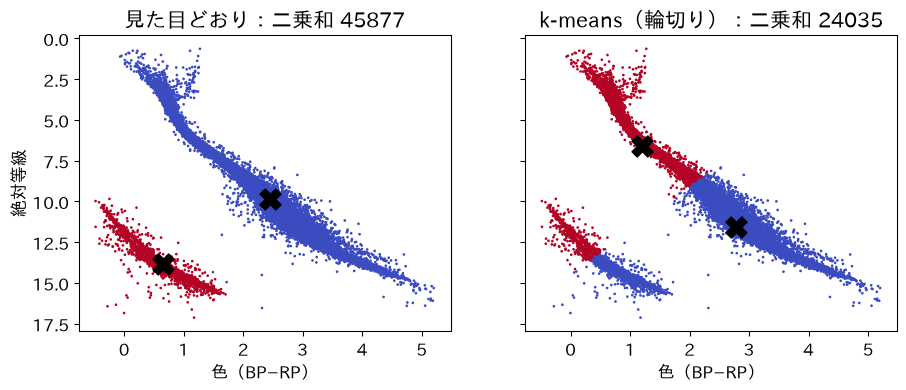

> 今日の重要概念（統計）：k-meansは丸い群を探す

> k-meansは、中心までの距離の二乗和を小さくする分け方を探す。だから丸くまとまった群を好み、細長い群は輪切りにする。

### 止まる所は1つか？

3節の最後に、見た目どおりの分け方から始めても、そこで止まりました。k-meansは、出発点から、二乗和が下がる向きにだけ動き、下がらなくなったら止まります。止まった所が、いちばん低いとは限りません。これを局所解といいます。

下の図のセルは、3つに分けるとき、出発点をでたらめに20通り替えて、止まった二乗和を数えます。中身は読み飛ばしてかまいません。

```
いちばん小さい二乗和 14038  20回のうち届いた回数 2
```

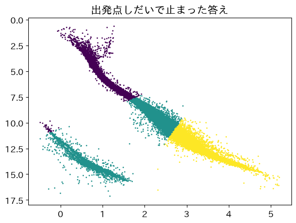

いちばん小さい二乗和14038に届いたのは、20回のうち2回だけです。止まった答えでは、白色矮星が、主系列の中ほどと同じ群に入ります。TODO①で3つに分けた図と見比べてください。

2節からの`n_init=10`は、出発点を10通り試し、二乗和がいちばん小さい答えを残す設定です。TODO①の3つの群も、こうして選ばれていました。さきほどの「見た目どおりでも止まる」も、同じ局所解の話でした。

> 重要：k-meansは、止まった所がいちばん良いとは限らない（局所解）。出発点を何通りも試し、二乗和がいちばん小さい答えを選ぶ。

### TODO②：出発点を替える（予想 → 実行 → 比べる）

下のセルは、出発点の2つの星から、割り当てと更新を動かなくなるまでくり返し、目安の線と組ごとに数えます。番号6の星は、白色矮星です。

まず、予想を書いてください。白色矮星の星を出発点にすれば、白色矮星の群ができるでしょうか。

（ここに予想を書く）

予想を書いたら、セルの`[0, 1]`を`[0, 6]`に替えて実行してください。

```python
# TODO: [0, 1] を [0, 6] に替えて実行する（6番の星は白色矮星）
C = X[[0, 1]]
moved = 1.0
while moved > 0:
    lab_x = assign(X, C)
    C_new = update(X, lab_x)
    moved = np.abs(C_new - C).max()
    C = C_new
pd.crosstab(df['白色矮星'], lab_x)
```

| col_0 白色矮星 | 0 | 1 |
| --- | --- | --- |
| 0 | 18394 | 7439 |
| 1 | 1428 | 599 |

### やってみよう：予想と比べる

実行した結果を、予想と比べてください。白色矮星の群はできましたか。

（ここに答えを書く）

白色矮星から始めても、白色矮星の群はできません。白色矮星は2つの群に割れ、止まった先は、ほぼ同じ輪切りです。下のセルで、二乗和も同じ24,035になることを確かめられます。出発点の星が白色矮星でも、1回目の更新で、中心は帯の平均へ引っぱられます。

```python
print(ss(X, lab_x))
```

```
24035
```

### ここまでで分かったこと

| 段 | 分かったこと |
| --- | --- |
| 知って分ける（1・2節） | HR図に主系列と白色矮星。k-meansで2つに分けると、白色矮星が1,422個と605個に割れる |
| くり返しを読む（3節） | 割り当てと平均を17回くり返して止まる。二乗和は輪切りが小さい。止まる所は出発点しだい |
| 群の数を決める（4節） | ？（このあとの段で） |
| つなぎ方を替える（5節） | ？（このあとの段で） |

まだ分からないのは、群の数をいくつにすればよいか、です。

## 4. 何個に分ければよい？

ここから、段3「群の数を決める」（4節）です。問いは、群の数は何個にすればよいか、です。

k-meansは、割り当てと更新を、中心が動かなくなるまでくり返します。中心までの距離の二乗和を小さくするので、長い主系列は輪切りになります。ここまで、群の数は2や3と、こちらで決めて渡してきました。

k-meansは、群の数を渡さないと動きません。答えの列が無いので、正解率のような物差しも使えません。データから、群の数の目安を出す指針がいくつかあります。今日は3つ並べます。

### お手本：群の数ごとの二乗和

- 役割：群の数を1から8まで替えて、二乗和をリストにためる
- 入力：配列`X`
- 出力：リスト`ws`（8つの二乗和）

```python
ws = []
for k in range(1, 9):
    km_k = KMeans(k, n_init=10, random_state=0)
    km_k.fit(X)
    ws.append(km_k.inertia_)
print(np.round(ws, 1))
```

```
[55720.  24035.6 14037.7  7671.1  5005.1  3716.1  2973.2  2434.9]
```

#### 1行ずつ読む

- 1行目：空のリスト`ws`を用意する（第4回）
- 2〜4行目：群の数`k`を1から8まで替えて、k-meansを当てはめる
- 5行目：二乗和（`inertia_`）をリストの後ろに足す
- 6行目：8つの二乗和を表示する

### お手本：二乗和を描く

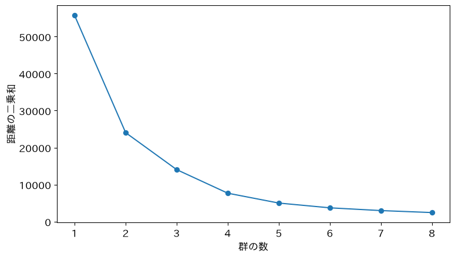

```python
plt.plot(range(1, 9), ws, 'o-')
plt.xlabel('群の数')
plt.ylabel('距離の二乗和')
plt.show()
```

群を増やせば、どの星も中心に近くなるので、二乗和は必ず下がります。下がり方が急にゆるむ点（エルボー）の数を選ぶ考えを、エルボー法といいます。この曲線だけでは、エルボーがどこか読みにくいので、下がり幅を数で見ます。

### お手本：下がり幅を見る

```python
drops = []
for k in range(1, 8):
    drops.append(round(ws[k - 1] - ws[k]))
print(drops)
```

```
[31684, 9998, 6367, 2666, 1289, 743, 538]
```

#### 1行ずつ読む

- 1行目：下がり幅をためる、空のリストを作る
- 2・3行目：群の数を1つ増やしたときに、二乗和がどれだけ下がったか（前の二乗和 − 次の二乗和）をためる。`ws[0]`が群1つ
- 4行目：7つの下がり幅を表示する

1つから2つで31,684下がり、2つから3つでは9,998です。そこから下がり方が急にゆるみます。エルボー法なら2つです。

### Gap統計の考え

群の無いデータでも、群を増やせば二乗和は下がります。そこで、群の無い偽のデータを作り、同じようにk-meansをかけて比べます。本物の二乗和が、偽より大きく下がった分だけ、本物には群があると考えます（Gap統計）。

偽の星は、本物と同じ範囲に、一様（uniform）にばらまいて作ります。帯も塊もありません。

### お手本：偽の星を作る

- 役割：本物と同じ範囲に、同じ数の偽の星を一様にばらまく
- 入力：配列`X`（列ごとの最小と最大、形）
- 出力：配列`fake`

```python
rng = np.random.default_rng(0)
fake = rng.uniform(X.min(axis=0), X.max(axis=0), size=X.shape)
print(fake[:3].round(2))
```

```
[[ 0.83 -1.76]
 [-2.61 -3.22]
 [ 1.84  1.94]]
```

#### 1行ずつ読む

- 1行目：乱数を作る道具を、シード0で用意する
- 2行目：列ごとの最小から最大までの範囲に、本物と同じ数の星を一様にばらまく
- 3行目：先頭3つの偽の星を見る

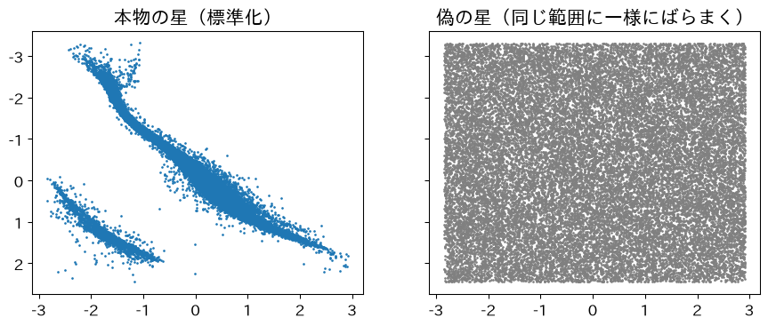

### 式：Gap

群の数$k$の本物の二乗和を$W_k$、偽の二乗和を$W_k^{*}$とします。

$$\mathrm{Gap}(k) = \overline{\log W_k^{*}} - \log W_k$$

偽は5組作り、$\log W_k^{*}$を平均します（上の線）。Gapが、次の群の数でもう伸びなくなる、いちばん小さい$k$を選びます。

### お手本：二乗和の対数を返す関数

本物にも偽にも同じ手順を当てるので、関数にします（第7回）。

- 役割：表`Z`を群の数`k`で分け、二乗和の対数を返す
- 入力：配列`Z`と群の数`k`
- 出力：二乗和の対数

```python
def log_w(Z, k):
    km_z = KMeans(k, n_init=10, random_state=0)
    km_z.fit(Z)
    return np.log(km_z.inertia_)
```

#### 1行ずつ読む

- 1行目：関数`log_w`を作る。入力は配列`Z`と群の数`k`
- 2・3行目：群の数`k`で、`Z`にk-meansを当てはめる
- 4行目：二乗和の対数（`np.log`は自然対数）を返す

### お手本：群の数ごとのGap

- 役割：群の数を1から8まで替え、偽の星5組と本物で二乗和の対数を出して、Gapをためる
- 入力：配列`X`、関数`log_w`
- 出力：リスト`gaps`（8つのGap）

少し時間がかかります（数十秒）。

```python
rng = np.random.default_rng(0)
gaps = []
sds = []
for k in range(1, 9):
    fake_w = []
    for b in range(5):
        fake = rng.uniform(X.min(axis=0), X.max(axis=0), size=X.shape)
        fake_w.append(log_w(fake, k))
    gaps.append(np.mean(fake_w) - log_w(X, k))
    sds.append(np.std(fake_w) * np.sqrt(1 + 1 / 5))
print(np.round(gaps, 3))
```

```
[1.016 1.387 1.468 1.617 1.872 2.006 2.06  2.095]
```

#### 1行ずつ読む

- 1〜3行目：乱数の道具をシード0で用意し直し、空のリスト`gaps`と`sds`を作る
- 4行目：群の数`k`を1から8まで替える
- 5行目：その`k`での、偽の二乗和の対数をためるリストを作る
- 6〜8行目：偽の星を5組作り、それぞれの二乗和の対数をためる
- 9行目：偽の平均から本物を引いたGapを、`gaps`に足す
- 10・11行目：偽の5組の揺れ`s`を`sds`にためる（あとで使う）。8つのGapを表示する

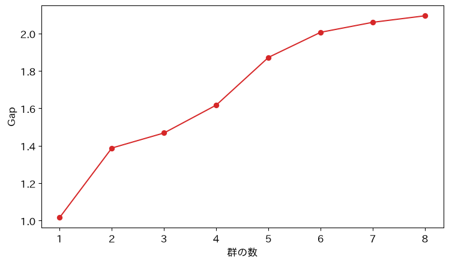

```python
plt.plot(range(1, 9), gaps, 'o-', color='tab:red')
plt.xlabel('群の数')
plt.ylabel('Gap')
plt.show()
```

えっ、Gapは、群を増やすたびに伸び続けます。8までに、伸びが止まる数がありません。

長い主系列は、細かく切るほど、本物の二乗和が大きく下がります。偽の星には帯が無いので、そこまでは下がりません。Gapも、k-meansと同じ「中心までの距離」の物差しで測っているのです。

### Gapの規則：揺れを入れる

偽の星は乱数で作るので、Gapにも揺れがあります。偽の5組の$\log W_k^{*}$の標準偏差を使って、揺れ$s_k$を決めます（上のセルの`sds`）。選ぶのは、

$$\mathrm{Gap}(k) \ge \mathrm{Gap}(k+1) - s_{k+1}$$

を満たす、いちばん小さい$k$です。次の数で伸びても、その伸びが揺れより小さければ、伸びていないとみなします。

### お手本：規則で選ぶ

```python
for k in range(1, 8):
    print(k, gaps[k - 1] >= gaps[k] - sds[k])
```

```
1 False
2 False
3 False
4 False
5 False
6 False
7 False
```

#### 1行ずつ読む

- 1行目：群の数`k`を1から7まで替える
- 2行目：`gaps[k - 1]`が群`k`のGap、`gaps[k]`と`sds[k]`が群`k + 1`のGapと揺れ。規則を満たせばTrue

揺れはごく小さく、どの数でも、次の数のGapのほうがはっきり大きいので、規則を満たす数は1〜7のどこにもありません。Gapは群の数を選びません。

### シルエットの考え

星ごとに、自分の群の中の近さ$a_i$（同じ群の星までの距離の平均）と、となりの群までの近さ$b_i$（いちばん近い別の群の星までの距離の平均）を比べます。

$$s_i = \frac{b_i - a_i}{\max(a_i, b_i)}$$

自分の群の中で近く、となりの群から遠いほど、1に近くなります。全部の星の$s_i$を平均し（シルエット）、いちばん大きい群の数を選びます。

### お手本：シルエット

- 役割：群の数を2から8まで替えて、シルエットをリストにためる
- 入力：配列`X`
- 出力：リスト`sils`（7つのシルエット）

```python
from sklearn.metrics import silhouette_score
sils = []
for k in range(2, 9):
    lab_k = KMeans(k, n_init=10, random_state=0).fit_predict(X)
    sils.append(silhouette_score(X, lab_k, sample_size=5000,
                                 random_state=0))
print(np.round(sils, 3))
```

```
[0.571 0.636 0.536 0.528 0.505 0.497 0.488]
```

#### 1行ずつ読む

- 1行目：シルエットの道具を呼び出す
- 2行目：空のリスト`sils`を用意する
- 3・4行目：群の数を2から8まで替え、当てはめて群の番号を出す（`fit_predict`）
- 5・6行目：シルエットを出してためる。計算が重いので、5,000個を抜き出して測る
- 7行目：7つのシルエットを表示する

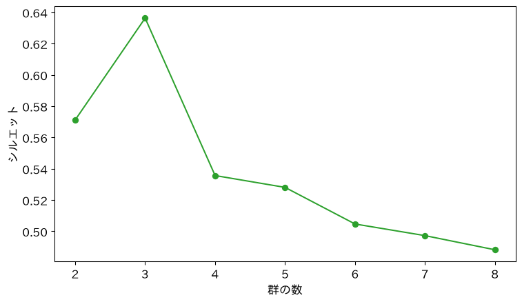

```python
plt.plot(range(2, 9), sils, 'o-', color='tab:green')
plt.xlabel('群の数')
plt.ylabel('シルエット')
plt.show()
```

3つに分けたときが、いちばん大きくなりました。2節のTODO①で見たとおり、3つに分けると、白色矮星が1つの群になり、主系列は明るい側と暗い側に切られます。

### お手本：星ごとのシルエット

シルエットは、星ごとに出せます。群ごとの平均を見ると、どの群がまとまっているかが分かります。全部の星だと重いので、3,000個を抜き出します。

```python
from sklearn.metrics import silhouette_samples
rng = np.random.default_rng(0)
idx = rng.choice(len(X), 3000, replace=False)
lab3 = KMeans(3, n_init=10, random_state=0).fit_predict(X)[idx]
s3 = silhouette_samples(X[idx], lab3)
for g in range(3):
    print(g, (lab3 == g).sum(), round(s3[lab3 == g].mean(), 3))
```

```
0 2015 0.642
1 215 0.698
2 770 0.579
```

#### 1行ずつ読む

- 1〜3行目：星ごとのシルエットを出す道具を呼び、3,000個を抜き出す
- 4・5行目：3つに分けた群の番号のうち、抜き出した星の分を取り、星ごとのシルエットを出す
- 6・7行目：群ごとに、星の数とシルエットの平均を表示する

白色矮星の群1（215個）が0.698でいちばんまとまります。主系列を輪切りにした群2（770個）は0.579です。

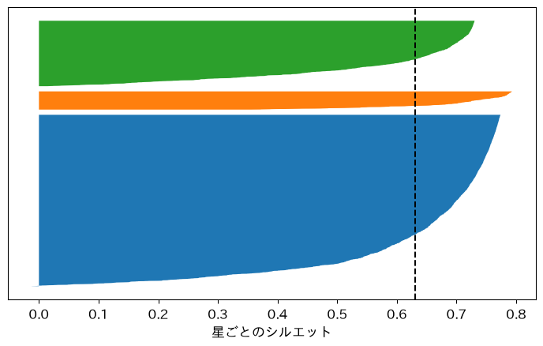

> 重要：群の数の指針は、数を1つ出してくれる。でも、その指針もk-meansと同じ距離の物差しで測っている。最後は、群の中身を読んで決める。

### TODO③：群の数の範囲を替える（予想 → 実行 → 比べる）

下のセルは、群の数を1から8まで替えて、Gapを出します。

まず、予想を書いてください。12まで増やすと、Gapはどこかで伸びが止まるでしょうか。

（ここに予想を書く）

予想を書いたら、セルの`9`を`13`に替えて実行してください（1分ほどかかります）。

```python
# TODO: 9 を 13 に替えて実行する（少し時間がかかる）
rng = np.random.default_rng(0)
gaps_x = []
for k in range(1, 9):
    fake_w = []
    for b in range(5):
        fake = rng.uniform(X.min(axis=0), X.max(axis=0), size=X.shape)
        fake_w.append(log_w(fake, k))
    gaps_x.append(np.mean(fake_w) - log_w(X, k))
print(np.round(gaps_x, 3))
```

```
[1.016 1.387 1.468 1.617 1.872 2.006 2.06  2.095]
```

### やってみよう：予想と比べる

実行した結果を、予想と比べてください。Gapの伸びは、どこかで止まりましたか。

（ここに答えを書く）

12まで増やしても、Gapは伸び続けます。主系列は、いくらでも細かく切れます。Gapの規則では、群の数が決まりません。

### ここまでで分かったこと

| 段 | 分かったこと |
| --- | --- |
| 知って分ける（1・2節） | HR図に主系列と白色矮星。k-meansで2つに分けると、白色矮星が1,422個と605個に割れる |
| くり返しを読む（3節） | 割り当てと平均を17回くり返して止まる。二乗和は輪切りが小さい。止まる所は出発点しだい |
| 群の数を決める（4節） | エルボーは2、シルエットは3。Gapは標準誤差を入れても、どの数も選ばない |
| つなぎ方を替える（5節） | ？（このあとの段で） |

まだ分からないのは、細長い帯を、帯のまま1つの群にできるか、です。

## 5. 帯のまま分けられる？

ここから、段4「つなぎ方を替える」（5節）です。問いは、細長い帯を、帯のまま1つの群にできるか、です。

k-meansは、中心までの距離の二乗和を小さくするので、長い主系列を輪切りにしました。群の数の指針も、同じ物差しで測っているので、Gapは止まりませんでした。そこで、群の数ではなく、何を「近い」と見るか、そのものを替えてみます。

### 階層的クラスタリング

はじめは、星1つずつが1つの群です。いちばん近い2つの群を1つにつなぐことを、全部が1つになるまでくり返します。これを、階層的クラスタリング（hierarchical clustering）といいます。つないだ順番を木の形に描いたものを、樹形図（デンドログラム）といいます。

樹形図を、ある高さで横に切ると、その下につながった塊が群になります。群の数を先に決めなくても、樹形図を見てから決められます。

群と群の近さを、どう測るかを決める必要があります。これを、つなぎ方といいます。

- 単連結：2つの群の中で、いちばん近い星どうしの距離
- ウォード法（Ward’s method）：つないだとき、中心までの二乗和がどれだけ増えるか（k-meansと同じ物差し）

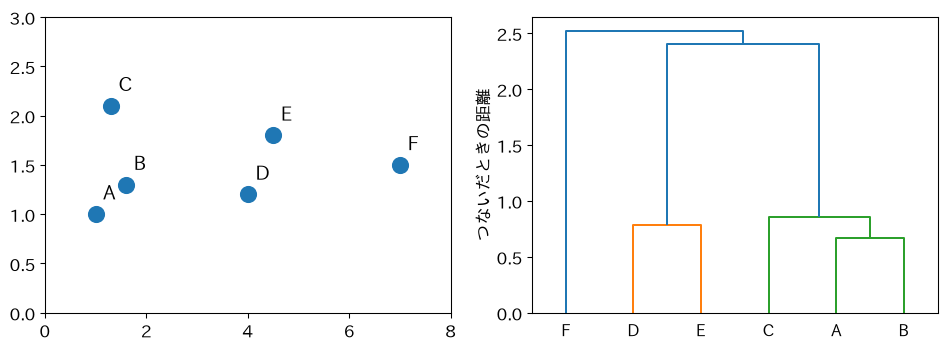

近いAとBが最初につながります。樹形図の高さは、つないだときの距離です。いちばん上の手前で切ると、A〜EとFの2つの群になります。

### お手本：3,000個を抜き出す

階層的クラスタリングは、すべての星の組の距離を使います。27,860個だと、組は約3億9千万で、Colabでは重くなります。そこで、でたらめに3,000個を選んで分けます。

- 役割：星の番号を重ならないように3,000個選び、その行の表と標準化した値を取り出す
- 入力：表`df`と配列`X`
- 出力：表`sub`と配列`Xs`

```python
rng = np.random.default_rng(0)
idx = rng.choice(len(df), 3000, replace=False)
sub = df.iloc[idx]
Xs = X[idx]
print(len(sub), sub['白色矮星'].sum())
```

```
3000 215
```

#### 1行ずつ読む

- 1・2行目：乱数の道具をシード0で用意し、星の番号を、重ならないように（`replace=False`）3,000個選ぶ
- 3・4行目：選んだ番号の行の表`sub`と、標準化した値`Xs`
- 5行目：星の数と、その中の白色矮星の数（215個）

### お手本：単連結で2つに分ける

- 役割：単連結の階層的クラスタリングで2つに分け、目安の線と突き合わせる
- 入力：配列`Xs`
- 出力：群の番号`lab_s`と、組ごとの数の表

```python
from sklearn.cluster import AgglomerativeClustering
ag = AgglomerativeClustering(2, linkage='single')
lab_s = ag.fit_predict(Xs)
pd.crosstab(sub['白色矮星'], lab_s)
```

| col_0 白色矮星 | 0 | 1 |
| --- | --- | --- |
| 0 | 0 | 2785 |
| 1 | 215 | 0 |

#### 1行ずつ読む

- 1・2行目：階層的クラスタリングの道具を呼び出し、群の数2、つなぎ方は単連結（`single`）で準備する
- 3行目：つないでいき、2つの群になったところで止めて、群の番号を出す
- 4行目：目安の線（1が白色矮星）と、群の番号を突き合わせる（2節と同じ）

#### 中身を見る：群ごとの星の数

`bincount`は、番号0・1ごとの数を数えます。

```python
print(np.bincount(lab_s))
```

```
[ 215 2785]
```

215個と2,785個です。目安の線の数と同じです。えっ、同じ3,000個で、k-meansは白色矮星を割りましたが、単連結は主系列と白色矮星を、そのまま分けました。

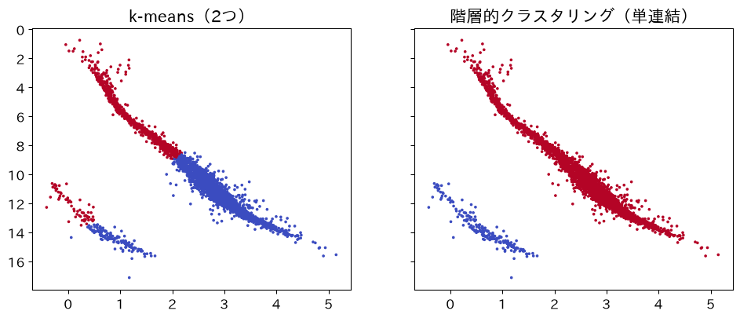

```python
fig, axes = plt.subplots(1, 2, figsize=(12, 4.5), sharey=True)
axes[0].scatter(sub['色'], sub['絶対等級'], s=3, c=df['群'].values[idx], cmap='coolwarm')
axes[0].set_title('k-means（2つ）')
axes[1].scatter(sub['色'], sub['絶対等級'], s=3, c=lab_s, cmap='coolwarm')
axes[1].set_title('階層的クラスタリング（単連結）')
axes[0].invert_yaxis()
plt.show()
```

単連結は、隣の星から隣の星へ、鎖のようにつなぎます。帯の中はすき間が小さいので、1本の鎖になります。2つの帯のあいだのすき間だけが大きく、最後までつながりません。

### お手本：樹形図を描く

```
[0.353 0.462 1.323]
```

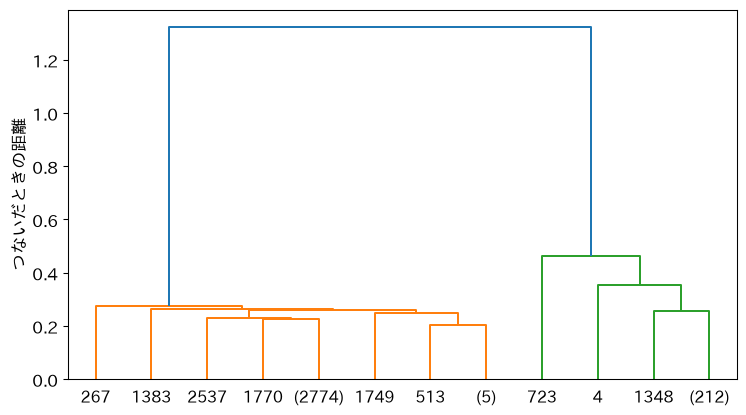

```python
from scipy.cluster.hierarchy import linkage, dendrogram
Z = linkage(Xs, 'single')
print(Z[-3:, 2].round(3))
dendrogram(Z, truncate_mode='lastp', p=12)
plt.ylabel('つないだときの距離')
plt.show()
```

#### 1行ずつ読む

- 1・2行目：樹形図の道具を呼び、単連結でつないだ順番と距離を`Z`にしまう（1行が1回のつなぎ）
- 3行目：最後の3回のつなぎの距離（`Z`の3列目）
- 4〜6行目：樹形図を描く。`truncate_mode='lastp', p=12`は、上の12本だけを描く指定

最後の1回だけが1.323で、その前は0.462より低くなっています。最後のつなぎの手前で切ると、2つの群です。樹形図から、群の数の目安も読めます。

### お手本：ウォード法の樹形図

```
[24.  42.9 50.6 74.5]
```

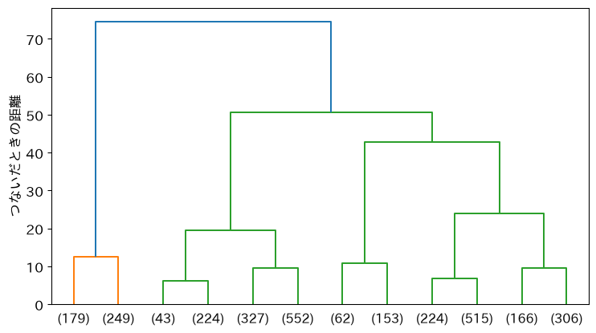

```python
Zw = linkage(Xs, 'ward')
print(Zw[-4:, 2].round(1))
dendrogram(Zw, truncate_mode='lastp', p=12)
plt.ylabel('つないだときの距離')
plt.show()
```

1行目だけが単連結と違います（`'ward'`）。最後の4回の高さは24.0・42.9・50.6・74.5で、42.9と24.0のあいだが大きく空きます。そこで切ると4つです。単連結の樹形図は2つを指しました。つなぎ方を替えると、樹形図が指す群の数も変わります。

### 単連結の弱点

3つに分けてみます。

```python
lab_s3 = AgglomerativeClustering(3, linkage='single').fit_predict(Xs)
print(np.bincount(lab_s3))
```

```
[ 214 2785    1]
```

離れた星1個だけの群ができます。単連結は、離れた点を1つずつ切り出しやすいのです。

### えっ、シルエットは輪切りを選ぶ

帯のまま分けた単連結と、輪切りのk-means（2節の列「群」）を、同じ3,000個のシルエットで比べます。

```python
from sklearn.metrics import silhouette_score
print(round(silhouette_score(Xs, lab_s), 3))
print(round(silhouette_score(Xs, df['群'].values[idx]), 3))
```

```
0.48
0.563
```

帯のまま分けた単連結は0.48、輪切りのk-meansは0.563です。シルエットは、輪切りのほうを「良い」と言います。

シルエットは、同じ群の星までの距離の平均（$a$）と、となりの群までの距離の平均（$b$）で測ります。細長い帯では、帯の端の星は、同じ帯の反対の端から遠いので、$a$が大きくなり、シルエットは低く出ます。群の数の指針も、群の良さの指針も、中心や平均の距離で測るので、帯のような群は低く見積もられます。

> 重要：群と群の近さを、中心までの二乗和で測るか、いちばん近い星どうしで測るかで、見つかる群が変わる。帯のような群は、つながりで測ると帯のまま分かれる。

### TODO④：つなぎ方を替える（予想 → 実行 → 比べる）

下のセルは、階層的クラスタリングで2つに分け、目安の線と組ごとに数えます。`'ward'`は、k-meansと同じ二乗和の物差しでつなぎます。

まず、予想を書いてください。ウォード法でも、主系列と白色矮星に分かれるでしょうか。

（ここに予想を書く）

予想を書いたら、セルの`'single'`を`'ward'`に替えて実行してください。

```python
# TODO: 'single' を 'ward' に替えて実行する
ag_x = AgglomerativeClustering(2, linkage='single')
lab_x = ag_x.fit_predict(Xs)
pd.crosstab(sub['白色矮星'], lab_x)
```

| col_0 白色矮星 | 0 | 1 |
| --- | --- | --- |
| 0 | 0 | 2785 |
| 1 | 215 | 0 |

### やってみよう：予想と比べる

実行した結果を、予想と比べてください。主系列と白色矮星に分かれましたか。

（ここに答えを書く）

ウォード法では、白色矮星は主系列の暗い側と同じ群に入り、明るい側の428個が切り出されます。二乗和の物差しに戻すと、帯は帯のままになりません。

### ここまでで分かったこと

| 段 | 分かったこと |
| --- | --- |
| 知って分ける（1・2節） | HR図に主系列と白色矮星。k-meansで2つに分けると、白色矮星が1,422個と605個に割れる |
| くり返しを読む（3節） | 割り当てと平均を17回くり返して止まる。二乗和は輪切りが小さい。止まる所は出発点しだい |
| 群の数を決める（4節） | エルボーは2、シルエットは3。Gapは標準誤差を入れても、どの数も選ばない |
| つなぎ方を替える（5節） | 単連結の階層的クラスタリングなら、主系列2,785個と白色矮星215個に分かれる |

4つの段がそろい、今日の問いに答えられます。

### 答え

k-meansで2つに分けると、主系列と白色矮星には分かれません。白色矮星が真っ二つになります。k-meansは中心までの距離の二乗和を小さくするので、長い主系列を輪切りにします。群の数は、エルボー法なら2、シルエットなら3で、Gapは揺れの規則を入れても選びません。指針ごとに答えが違います。近い星どうしをつなぐ階層的クラスタリング（単連結）なら、2つの帯がそのまま分かれます。

まだ言えないこと

- 階層的クラスタリングは3,000個で試した。全部の星では、帯のあいだにも星が入り、鎖がつながってしまうことがある
- 2つの帯の境目にある星を、どちらの群とも言い切らない扱い
- 指針どうしが食い違ったとき、どれを信じるか

### レポートなら、こう書く

今日の解析を、期末レポートの項目に写すと、次のようになります。

- 予想：2つに分ければ、主系列と白色矮星に分かれるだろう
- 解析：色と絶対等級を標準化し、k-meansで2つに分けた
- 驚き：白色矮星が2つの群に割れた。目安の線と比べると、1,422個と605個
- 理由：見た目どおりの分け方は、二乗和が45,877で、輪切り（24,035）の2倍近い
- 群の数：エルボーは2、シルエットは3が最大、Gapは揺れの規則でも選ばない。3つの群の中身を読んで決めた
- 別の方法：単連結の階層的クラスタリングなら、3,000個で主系列2,785個と白色矮星215個にぴったり分かれた

## 目標に答えられたか

- 今日の目標は「答えの列が無い星を、似たものどうしでまとめると、星の種類が分かれるか。何個に、どう分ければよいか」でした。HR図と群の図と、二乗和・指針の数・樹形図で答えられますか？
- 1節で、見かけの等級でなく絶対等級を使ったのはなぜですか？
- 2節で、k-meansの前に標準化したのはなぜですか？
- 3節で、`while`の条件`moved > 0`は、何を確かめていましたか？`for`では書きにくいのはなぜですか？
- 3節で、見た目どおりの分け方でも止まるのに、`KMeans`が輪切りを選んだのはなぜですか？
- 4節で、Gapが伸び続けたのはなぜですか？
- 5節で、単連結なら2つの帯がそのまま分かれたのはなぜですか？ウォード法ではどうなりましたか？

## 今日の要点

- 今日、持ち帰る1文：k-meansは、近い中心に割り当てて中心を平均へ動かすことを、動かなくなるまでくり返す。距離の二乗和を小さくするので、丸い群を探し、細長い群は輪切りにする。近い星どうしをつなぐ階層的クラスタリングなら、帯は帯のまま分かれる
- 重要概念（統計）：k-meansは丸い群を探す。中心までの距離の二乗和を小さくする分け方を探すので、細長い群は輪切りにする
- 重要概念（Python）：while。条件を満たすあいだ、くり返す。何回で終わるかが先に決まらないくり返しに使う
- 距離で分ける前に、列の単位をそろえる（標準化）
- 群の番号は名前にすぎない。群の数の指針も、距離の物差しの上に立つ
- 何を「近い」と見るか（つなぎ方）を替えると、見つかる群が変わる

## 次回へ

今日のk-meansと階層的クラスタリングは、星を1つの群に言い切りました。では、群の形が楕円でもよく、境目の星を「どちらの群か、確率で」言える分け方はあるでしょうか。

## 課題（提出）

提出するもの：絵2枚（画像ファイル）。今日の重要概念の、統計とPythonを1枚ずつです。提出フォームから出してください。期限はありません。

コードは書きません。上手な絵である必要はありません。紙に手で描いて写真を撮っても、描画アプリで描いてもかまいません。

### 今日の重要概念（2つ）

- 統計：k-meansは丸い群を探す。中心までの距離の二乗和を小さくする分け方を探すので、細長い群は輪切りにする（3節）
- Python：while。条件を満たすあいだ、くり返す。何回で終わるかが先に決まらないくり返しに使う（3節）

### 今日の2枚（絵にする）

2つの重要概念を、1枚ずつ絵にしてください。その考えが1枚で伝わる絵です。数式やコードは描かなくてかまいません。半年後の自分が見て、何の話だったか思い出せる絵を目指します。

**詰まったら**

k-meansは丸い群を探す、なら、たとえば「細長い商店街の売店」を描けます。 売店を2つ置き、客はいちばん近い売店へ行きます。売店は、客の多いところへ少しずつ動きます。すると商店街は、真ん中で2つに切られます。通りの東と西という「見た目の2つ」とは限りません。3節の「見た目どおり」と「輪切り」を並べた図が手本になります。

**詰まったら**

whileなら、たとえば「お風呂にお湯を足す」を描けます。 「ぬるいあいだは、足す」。何杯で終わるかは、やってみるまで分かりません。ちょうどよくなったら止めます。3節の`x`を2倍し続ける例や、二乗和が下がっていく図が手本になります。

## 発展（任意）

### 出発点を賢く選ぶ

3節の`init='random'`は、星をでたらめに選んで出発点にしました。`KMeans`の決まりの選び方（k-means++）は、互いに離れた星を選びやすくします。同じ20通りで、いちばん小さい二乗和に届く回数を比べます。

```python
ss_pp = []
for s in range(20):
    km_s = KMeans(3, n_init=1, random_state=s)
    km_s.fit(X)
    ss_pp.append(round(km_s.inertia_))
print(min(ss_pp), ss_pp.count(min(ss_pp)))
```

```
14038 11
```

#### 1行ずつ読む

- 3行目：`init`を書かないと、k-means++で出発点を選ぶ
- ほかの行は、3節のお手本と同じ

20回のうち11回が、いちばん小さい二乗和14038に届きました。でたらめ（2回）より、ずっと多くなります。それでも全部ではないので、`n_init`で何通りも試します。

試すなら、群の数を4や5にして、届く回数を比べてみましょう。